# Package RanglaPunjab

Sonia Bhar Ahluwalia

2018-07-27

R code that defines color palettes based on the [unique, vibrant culture of Punjab, India](https://www.youtube.com/watch?v=wDheWYmNEhQ).

Rangla Punjab translates to “Colorful Punjab”.

And if you ever visit India, [Rangla Punjab](https://haveli.co/rangla-punjab/) is a wonderful Punjabi theme village of generations gone by.

In the meantime, enjoy this R package :-)

## Functions

Rangla Punjab: `RanglaPunjab(name)`

List Palette: `ListPalette()`

Merge Palette: `MergePalette(name, name2, name3)`

Paint Palette: `PaintPalette(name, name2, name3)`

Cherry Pick Palette: `CherryPickPalette(name, name2, name3)`

Show Palette Photo: `ShowPalettePhoto(name)`

## Sample Code

3-D Pie Chart

Bar Plot

## Rangla Punjab: `RanglaPunjab(name)`

Input 1 palette, return vector of colors

```r
> RanglaPunjab("GoldenTemple")
[1] "#bdcad0" "#5f8abf" "#ffd860" "#d88821" "#672006"
```

## List Palette: `ListPalette()`

Lists all 24 palettes

```r
> ListPalette()
 [1] "FieldsOfPunjab"       "FieldsOfPunjab2"        "GoldenTemple"           "GoldenTemple2"
 [5] "Pindh"                "Haveli"                 "Haveli2"                "AmritsariKulcha"
 [9] "CholeBhature"         "BiryaniRice"            "AmritsariLassi"         "AmritsariPedeWaliLassi"
[13] "Kulfi"                "SohniMahiwal"           "HeerRanjha"             "Gidha"
[17] "Gidha2"               "Teej"                   "Phulkari"               "Phulkari2"
[21] "Jutti"                "Jutti2"                 "Jutti3"                 "Paranda"
```

## Merge Palette: `MergePalette(name, name2, name3)`

Input 2 to 3 palettes to merge into new palette

```r
MergePalette("AmritsariKulcha", "Phulkari2")
[1] "#e3e4d9" "#ebdc9c" "#b3340e" "#67140a" "#2a231d" "#9c1a41" "#42a4e8" "#3a35da" "#ee523c" "#3e167c"
```

## Paint Palette: `PaintPalette(name, name2, name3)`

Input 1 to 3 palettes to display their colors on screen

[figure not shown]

```r
> PaintPalette("FieldsOfPunjab","Jutti","Paranda")
```

## Cherry Pick Palette: `CherryPickPalette(name, name2, name3)`

Input 2 to 3 palettes to visually select colors to create new palette. Will open interactive shiny app and save list of colors to`cherrypickedpalette`.

[figure not shown]

```r
> CherryPickPalette("GoldenTemple","GoldenTemple2")
```

## Show Palette Photo: `ShowPalettePhoto(name)`

Input 1 palette to display photo that inspired these colors

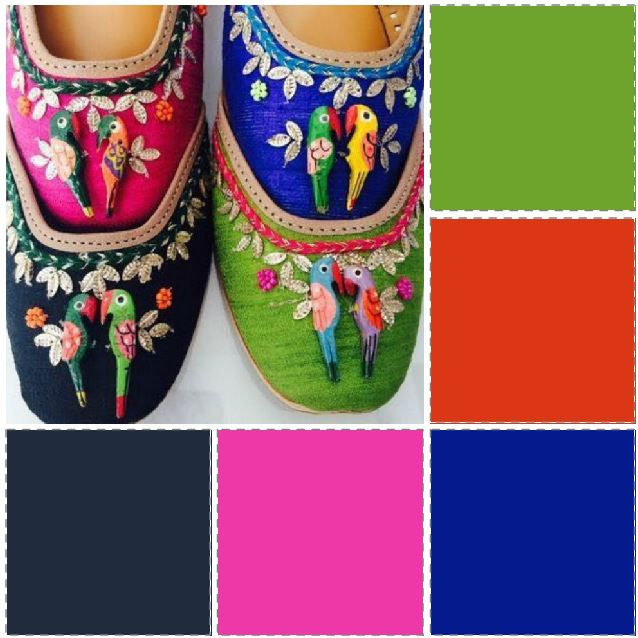

```r
> ShowPalettePhoto("Jutti3")
```

## 3-D Pie Chart

Use `RanglaPunjab` to color pie charts.

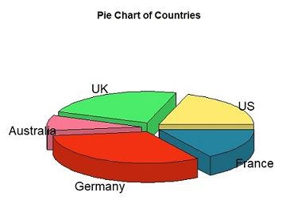

```r
library(RanglaPunjab)
library(plotrix)

slices <- c(10, 12, 4, 16, 8)
lbls <- c("US", "UK", "Australia", "Germany", "France")
pie3D(slices,labels=lbls, explode=0.1, col=RanglaPunjab("Gidha"), main="Pie Chart of Countries ")
```

## Bar Plot

Use `CherryPickPalette` to dynamically color bar plots.

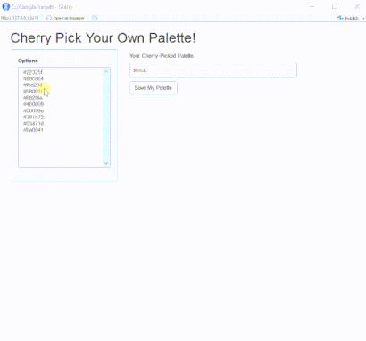

```r
library(RanglaPunjab)

counts <- table(mtcars$vs, mtcars$gear)
barplot(counts, main="Car Distribution by Gears and VS",
        xlab="Number of Gears", col=CherryPickPalette("Teej","Jutti"),
        legend = rownames(counts))
```